# Overheating in the Mitten: The Effects of Anthropogenic Climate Change on Farming in Michigan

Lila Rubin

October 2020

*The state of Michigan sits on land of multiple Indigenous communities: the Ojibwa, the Potawatomi, and the Odawa. Known as the Council of the Three Fires, the three nations were primarily farming communities, raising corn, beans, squash, and more. As we discuss modern agriculture, those of us who are settlers remember that this land is not ours to sow.*

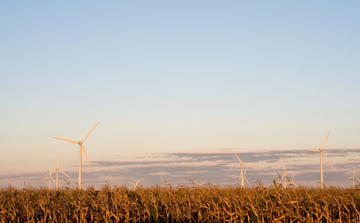

Coasts are ravaged by hurricanes, flooding, and wildfires. The central United States is plagued by drought, the South by heat waves (U.S. Global Change Research Program 2014). It is almost unanimously agreed in the scientific community that these drastic and deadly changes in climate are due to human-caused global warming (Cook, John, et al 2016). In the agricultural cradle of the U.S. known as the Midwest, however, citizens are seeing the effects of climate change in their backyard from a more subtle perspective. The production of staple crops like corn, wheat, beans, and squash, can actually benefit from the world’s rising temperature, as the warmer climate extends Michigan’s growing season (American Security Project). However, warmer temperatures are not the only symptom of climate change – increases in extreme weather events, for example, are common. This means that should climate change continue on its projected path, bumper crops one year may give way to empty siloes in the next, may lead to bumper crops in the third year, and so on and so forth. This blog examines and analyzes the impact of climate statistics and projections on the Michigan agriculture. While the rise in temperature may be beneficial to farmers in the Mitten at surface level, the dangers of unpredictable seasons lurk just below the rising water line. Climate change mitigation is essential to ensuring consistent, plentiful harvests for Michiganders and the rest of the world.

#### Data Retrieval and Analysis

In order to analyze the impacts of climate change on the state of Michigan, this blog will center around the analysis of climate data including minimum and maximum daily temperatures and precipitation levels in Ann Arbor, Michigan, from the October 1st of 1891 to September 2nd of 2020, in tandem with data on total corn yield and conditions in the entire state from 1866 to 2020. This statistical support is based on data curated by the National Oceanic and Atmospheric Administration (NOAA), which was collected at the University of Michigan (at weather station GHCND:USC00200230) in Ann Arbor. Agricultural data is curated by the National Agricultural Statistics Service (NASS). These freely available datasets can be analyzed for various trends using R (National Oceanic and Atmospheric Administration 2020; National Agricultural Statistics Service 2020). Close analysis of trends and patterns in this information, along with the review of other research done in the region, informed the conclusions which will be presented in this blog. It should be noted that we will focus on Ann Arbor data to paint a general picture of weather anomalies in the whole state of Michigan, but total state data for agricultural trends. We have chosen the University of Michigan’s weather station to represent state weather because of its extensive and consistent daily summaries of temperature and precipitation. In addition, Ann Arbor lies in the same plant hardiness zone of the major corn counties of Michigan. The term “plant hardiness zone” was created by the United States Department of Agriculture to identify similar ranges of climate conditions based on an area’s geographic location in order to better inform farmers on what crops could thrive in their area. The two images below show the correlation between Michigan’s plant hardiness zones and the frequency of corn crops from 2008 to 2019. We see that Ann Arbor is in Zones 5b and 6a similar to the rest of Michigan excluding the Upper Peninsula northern Lower Peninsula. We also see that these two zones correlate with the major corn producing areas of Michigan, which extend across the southern half of the mitten. Such information from the USDA shows us that Ann Arbor’s climate can act as an indication of climatic conditions across the state’s corn-growing regions.

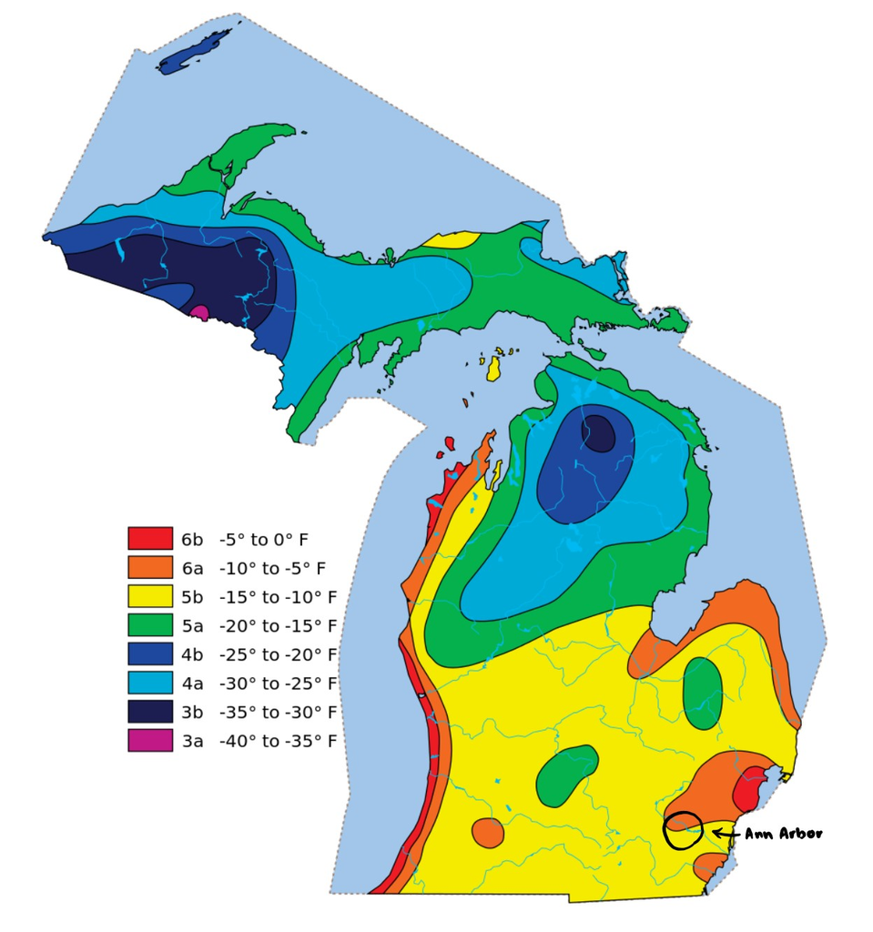

[figure not shown]

## Ecology and Economy

These numbers are certainly impressive, and as mentioned before, the warming climate may take partial credit for such high yields. As increased heat may wither crops in states south of Michigan, a solely warming climate actually benefits the formerly chilly Michigan. However, as trends in temperature maximums and minimums rise, so too do the frequency and intensity of extreme weather events. Increased risks of extreme heat and cold events, droughts and floods, and precipitation patterns threaten to disturb growing seasons and wreak havoc on field crop production (Winkler, Andresen, et al. 2014).

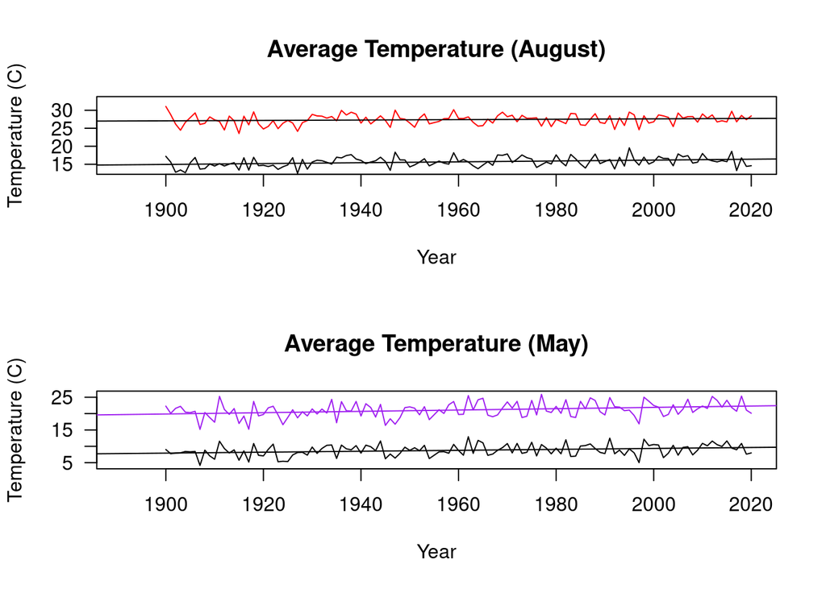

In order to analyze patterns in temperatures over the span of more than a century, I graphed the daily maximum and minimum temperatures of each month from 1891 to 2020. I chose to display the May and August results in this blog as May is generally the beginning of the growing season and August is nearing the end. Each month displays minimum and maximum temperature graphs with increasing slopes - however, there is always the possibility that data is statistically insignificant. To avoid misconstruing data or jumping to conclusions, we ran the graphs through a series of statistical analysis tests. 10 out of 12 months of average minimum temperatures (excluding January and October) proved to be highly statistically significant (p-values ranged from 0.022 to 0.0002), disproving the null hypothesis and showing that there is a strong correlation between increasing minimum temperatures and time. Interestingly, only half of the increasing slopes in maximum temperatures were statistically significant. Average maximum temperatures from February to June disprove the null hypothesis (p-values range from 0.010 to 0.00001), as do maximum temperatures in December. These significant trends from February to June indicate that Michigan springs and early summers are increasing in both minimum and maximum temperatures, and that the coldest month (December) is becoming more temperate. July to November, however, do not show statistically significant trends, nor does January. From this information we can conclude that late summer to late fall, along with the month of January, are relatively stagnant in terms of changes in temperature from between 1891 to 2020.

This data fits scientists’ predictions of longer and perhaps potentially more prosperous Michigan growing seasons. As temperatures increase in early spring, farmers are able to plant crops sooner, and crops like corn, which requires a longer growing season, still flourish in the steady temperatures of late summer and fall.

## Sowing Corn in Growing Temperatures

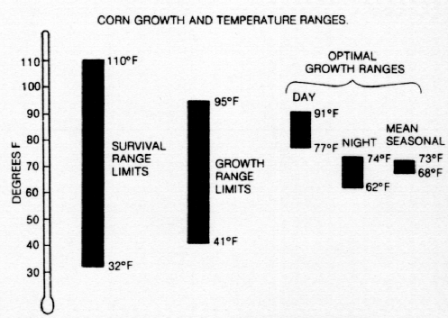

Source: Randall Schaetzl, Michigan State University

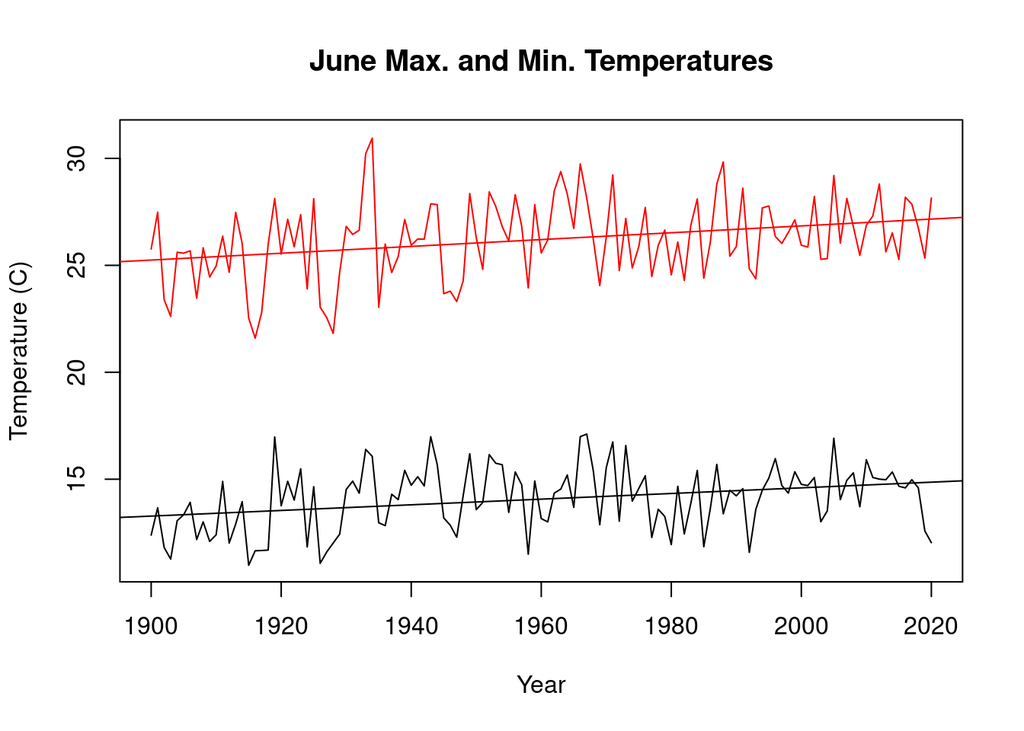

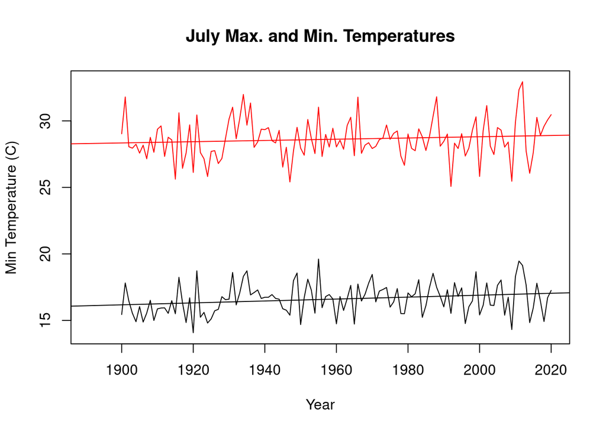

Increasing temperature alone can provide benefits to farmers - at least, for now. Based on the trends in our data, if no climate change mitigations are enacted, average temperatures in Michigan will increase by around 2 degrees within 100 years. A study published by the National Academy of Sciences, shown below, predicts that a 1°C increase in temperature could result in the loss of around 10% of corn yields in Champaign, Illinois - a close neighbor of Michigan who shares the same plant hardiness zone (Liang, Wu, et al. 2017).

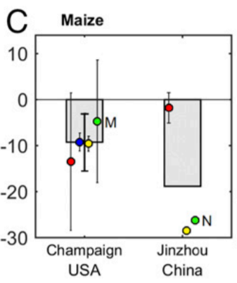

On top of this fact, climate change is predicted to accelerate if drastic measures are not taken to prevent the release of more greenhouse gases into the atmosphere (IPCC [Core Writing Team] 2014). This means that instead of temperatures growing at a linear pace, they will grow exponentially. In other words, even 1°C could make a huge difference in corn yields, *and* it is likely that 2 degrees in the next 100 years is an under-estimate. To add to all of this, increasing temperature is determinedly not the only result of climate change. The frequency of extreme and unpredictable weather events like heavy rain and flooding, flash freezes, and droughts, among others, has risen with the warming of the globe as well (Union of Concerned Scientists 2018). A 2019 study done by researchers at the University of Illinois showed that “excessive rainfall” could decrease corn crop yields by up to 34%, just as drought and heat waves can cause a decrease of up to 37% (Yoksoulian 2019). The unpredictability of these events are of great concern to scientists studying the Great Lakes State due to the food shortages and economic gravity, among many environmental impacts, that such events will bring about (Yoksoulian 2019; Winkler, Andresen, et al. 2014). And the consequences of extreme weather events already seem to be taking their toll on corn yields in Michigan.

## Predicting Production

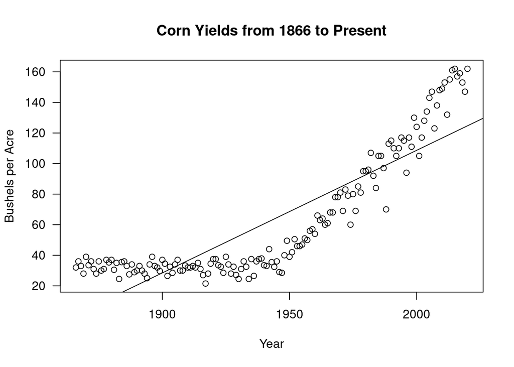

From this graph, we can see that corn yields were relatively similar and steady from the 1860s to the late 1940s. In the 1950s, however, corn production grew dramatically, easily surpassing even the bountiful harvests of years prior. As the 1900s drew to an end, we see the data spread, indicating a more drastic contrast between year-to-year yields than seen before. To explore this hypothesis, I’ve broken the graph into three eras: 1866 to 1920, the years of steady production; 1920 to 1970, in which yields take a sharp upturn; and 1970 to 2019, where our data spreads out. In order to measure the accuracy of the trends and examine differences in spreads of data, we will look both at the p-value and standard deviation of each line of best fit.

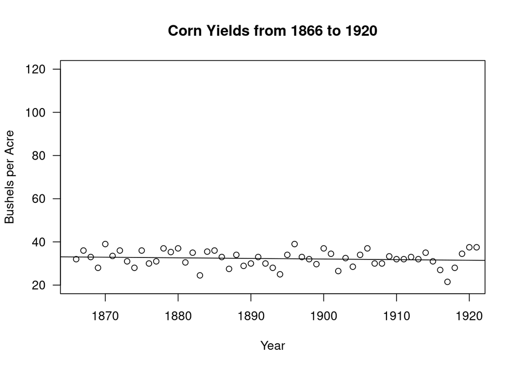

The downward trend from 1866 to 1920 is not statistically significant (p-value = 0.376) and can therefore be discounted as an indication of a decrease in corn productivity. The line’s standard deviation is low, sitting at 3.817, and indicates a steady period of corn production.

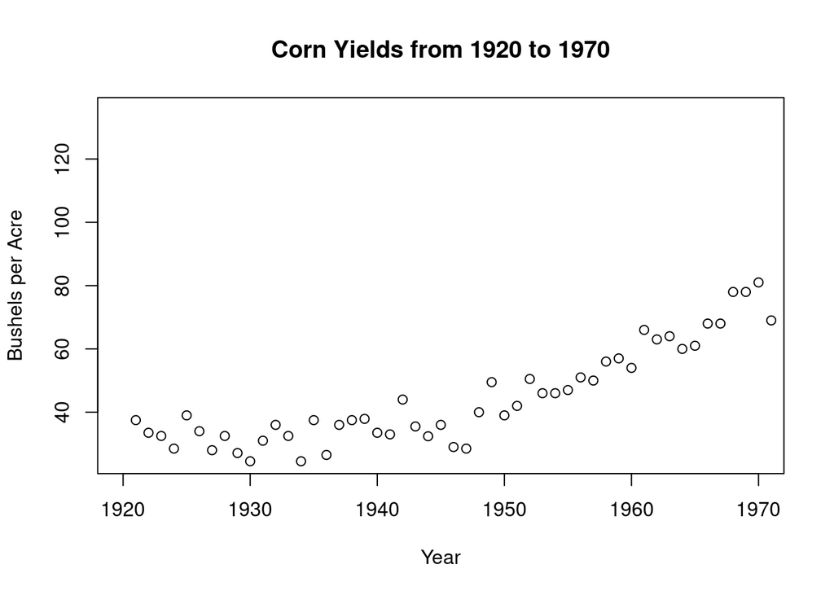

From 1920 to 1970, the increase in yield is well beyond the point of statistically significant (p-value = 2.2e-16), confirming that the era was indeed a time of extreme growth for the Michigan corn industry. We also see the data start to spread out, with a higher standard deviation of 15.345, a sign that something has caused less steady corn yields than our first era. 1920 is also just after the start of Industrial Revolution, which some scientists peg as the beginning of dramatic anthropogenic climate change as well (Cook, Oreskes, et al. 2016), and based on the research we have studied so far, one could infer that the two are linked.

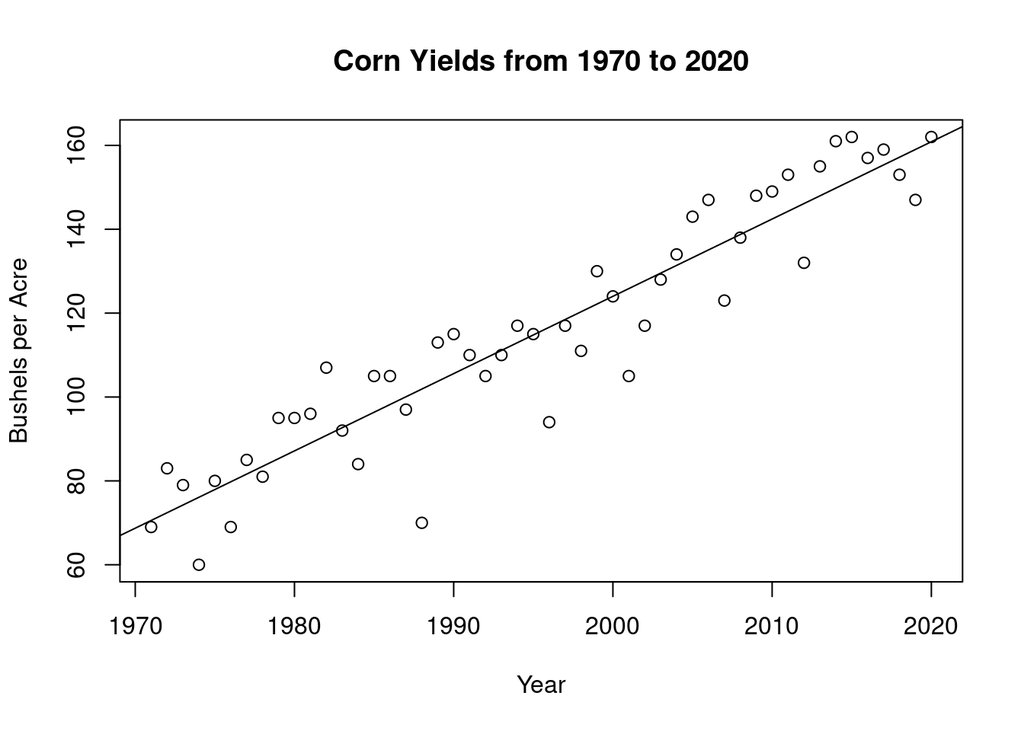

Lastly, we get to our most recent era, one that is currently taking place. The line of best fit still trends significantly upward, even more than before; this is the era where we see an even more heightened standard deviation of 28.691, indicating a growing disparity in the predictability of annual corn yields.

## Conclusions

Given the research conducted and cited above, there is strong reason to believe that the growing standard deviation in Michigan corn yields is at least in part due to the effects of climate change on the state. Although heightened temperatures may temporarily and occasionally benefit the mitten state’s agricultural industry, extreme temperature waves and increasingly erratic weather patterns have and will wreak havoc on the dependability of crop production for the population and the economy. Michigan is home to more than 52,000 farms, each with mouths to feed both on the farm, in their community, and around the world (Michigan Ag Council [date unknown]). Without a dependable harvest or income, families and communities will be left struggling to make ends meet under the pressures of empty siloes, stomachs, and savings accounts. With a primarily agriculture-based economic model, it will be difficult to adjust to a world in which conventional agriculture is unreliable due to extreme and unpredictable weather patterns (Kling, George W., et al). While scary to think about, this is also where some of the best change can be made.

Farmers have been and are beginning to focus more and more on creating sustainable practices. Organizations like Farmers for a Sustainable Future can make a huge difference in the fight for climate change mitigation because of their unique position to cut methane, nitrous oxide, and carbon dioxide emissions on their farms, from recycling water and using animal waste to generate electricity to creating their own natural fertilizer from manure and straw, practicing sustainable farming is a huge step in the fight to stop climate change (Hyson, Webb, et al. 2018). In addition, Farmers for Sustainable Future involves farmers around the country in grassroots organizing, political advocacy, and legal aid to integrate their industry into the fight for a greener future (American Farm Bureau Federation). Michigan farmers know better than anyone: although the signs are more subtle than fire or flood, Michigan’s climate crisis is just as grave and must be addressed with the utmost seriousness.

## References

1. U.S. Global Change Research Program. Climate change impacts in the United States. 2014. https://www.globalchange.gov/sites/globalchange/files/NCA3-climate-trends-regional-impacts-brochure.pdf
2. Cook J, Oreskes N, Doran PT, Anderegg WRL, Verheggen B, Maibach EW, Carlton JS, Lewandowsky S, Skuce AG, Green SA, et al. Consensus on consensus: a synthesis of consensus estimates on human-caused global warming. Environmental research letters. 2016;11(4):048002.
3. Epa US, REG. Facts and figures about the great lakes. 2015 [accessed 2020 Oct 11]. http://www.epa.gov/greatlakes/facts-and-figures-about-great-lakes
4. Jenny J-P, Anneville O, Arnaud F, Baulaz Y, Bouffard D, Domaizon I, Bocaniov SA, Chèvre N, Dittrich M, Dorioz J-M, et al. Scientists’ Warning to Humanity: Rapid degradation of the world’s large lakes. Journal of Great Lakes research. 2020;46(4):686–702.
5. Kling, George W., Katharine Hayhoe, Lucinda B. Johnson, John J. Magnuson, Stephen Polasky, Scott K. Robinson, Brian J. Shuter, Michelle M. Wander, Donald J. Wuebbles, Donald R. Zak, Richard L. Lindroth, Susanne C. Moser, Mark L. Wilson. Confronting Climate Change in the Great Lakes Region: Impacts on Our Communities and Ecosystems. Cambridge, MA: Union of Concerned Scientists; 2003. www.jstor.org/stable/resrep00033.10
6. American Security Project. Climate Change and the Threats to the American Midwest. American Security Project; 2014. www.jstor.org/stable/resrep05970
7. Julie A. Winkler, Jeffrey A. Andresen, Jerry L. Hatfield, David Bidwell, Daniel Brown. Climate Change in the Midwest: A Synthesis Report for the National Climate Assessment. Washington, D.C., DC: Island Press; 2014. https://www.researchgate.net/publication/278038317
8. Michigan Ag Council. Michigangrown.org. [accessed 2020 Oct 11]. https://michigangrown.org/
9. National Agricultural Statistics Service. Annual Statistical Bulletin: Economics. 2020. https://www.nass.usda.gov/Statistics_by_State/Michigan/Publications/Annual_Statistical_Bulletin/stats20/Economics.pdf
10. Yoksoulian L. Excessive rainfall as damaging to corn yield as extreme heat, drought. Phys.org. 2019 Apr 30 [accessed 2020 Oct 11]. https://phys.org/news/2019-04-excessive-rainfall-corn-yield-extreme.html
11. National Oceanic and Atmospheric Administration. ANN ARBOR U OF MICH, MI US: Daily Summaries. National Centers for Environmental Information. 2020.
12. National Agricultural Statistics Service. CORN, GRAIN - PRODUCTION, MEASURED IN BU. Quick Stats. 2020. https://quickstats.nass.usda.gov/results/B239FD85-E069-3E6E-AEC4-33D45EF8D084
13. National Agricultural Statistics Service. Cropland Data Layer. 2019. https://nassgeodata.gmu.edu/CropScape/
14. IPCC [Core Writing Team]. Climate Change 2014: Synthesis Report. In: R.K. Pachauri and L.A. Meyer, editor. Contribution of Working Groups I, II and III to the Fifth Assessment Report of the Intergovernmental Panel on Climate Change. Geneva, Switzerland: IPPC; 2014. p. 167.
15. Union of Concerned Scientists. The Science Connecting Extreme Weather to Climate Change. 2018.
16. Liang X-Z, Wu Y, Chambers RG, Schmoldt DL, Gao W, Liu C, Liu Y-A, Sun C, Kennedy JA. Determining climate effects on US total agricultural productivity. Proceedings of the National Academy of Sciences of the United States of America. 2017;114(12):E2285–E2292.
17. Hyson P, Webb L, Lowe S, Ackers K, Bingham R, Mathews B. Sustainable dairy farming - is it possible? Ecoandbeyond.co. 2018 May 2 [accessed 2020 Oct 15].
18. Advocacy - American Farm Bureau Federation. Www.fb.org. [accessed 2020 Oct 15]. https://www.fb.org/advocacy